# hw9

XianjieQue

2025-04-17

### load packages

```r
library(ggplot2)
library(ISLR2)
library(boot)
library(splines)
library(leaps)
library(glmnet)
# install.packages("gam")
library(gam)
```

Section 7.9

### Conceptual: 1

What I need to do is to show that a function of the form
$$f(x) = \beta_0 + \beta_1 x + \beta_2 x^2 + \beta_3 x^3 + \beta_4 (x -
\xi)^3_+$$
is a cubic regression spline with one knot at $\xi$.

#### (a)

Define $f_1(x)$ for $x \leq \xi$

When $x \leq \xi$, the truncated cubic term disappears:
$$(x - \xi)^3_+ = 0$$
So the function becomes:
$$f_1(x) = \beta_0 + \beta_1 x + \beta_2 x^2 + \beta_3 x^3$$
Thus, we can write it as a cubic polynomial:
$$f_1(x) = a_1 + b_1 x + c_1 x^2 + d_1 x^3$$
where:
$$a_1 = \beta_0 \\ b_1 = \beta_1 \\ c_1 =
\beta_2 \\ d_1 = \beta_3$$

#### (b)

Define $f_2(x)$ for $x > \xi$

For $x > \xi$, we expand the truncated cubic term:
$$(x - \xi)^3 = x^3 - 3\xi x^2 + 3\xi^2 x - \xi^3$$

So:
$$f(x) = \beta_0 + \beta_1 x + \beta_2 x^2 + \beta_3 x^3 + \beta_4(x -
\xi)^3\\
= (\beta_0 - \beta_4 \xi^3) + (\beta_1 + 3 \beta_4 \xi^2)x + (\beta_2 -
3 \beta_4 \xi) x^2 + (\beta_3 + \beta_4) x^3$$

This gives us another cubic polynomial:
$$f_2(x) = a_2 + b_2 x + c_2 x^2 + d_2 x^3$$

where:
$$a_2 = \beta_0 - \beta_4 \xi^3 \\ b_2 = \beta_1 + 3 \beta_4 \xi^2 \\
c_2 = \beta_2 - 3 \beta_4 \xi \\ d_2 = \beta_3 + \beta_4$$

#### (c)

Show that $f_1(\xi) = f_2(\xi)$, which means continuity at $\xi$

Compute:
$$f_1(\xi) = \beta_0 + \beta_1 \xi + \beta_2 \xi^2 + \beta_3 \xi^3$$

and:
$$f_2(\xi) = a_2 + b_2 \xi + c_2 \xi^2 + d_2 \xi^3\\
= (\beta_0 - \beta_4 \xi^3) + (\beta_1 + 3 \beta_4 \xi^2) \xi + (\beta_2
- 3 \beta_4 \xi) \xi^2 + (\beta_3 + \beta_4) \xi^3$$
After simplification, $f_2(\xi) = f_1(\xi)$
So the function is continuous at $\xi$

#### (d)

Show that $f_1'(\xi) = f_2'(\xi)$, which means first derivative continuity

Derivative of a cubic:
$$f'(x) = \beta_1 + 2\beta_2 x + 3\beta_3 x^2 + 3\beta_4(x - \xi)^2_+$$

At $x = \xi$, the last term is zero, so:
$$f_1'(\xi) = f_2'(\xi) = \beta_1 + 2\beta_2 \xi + 3\beta_3 \xi^2$$
First derivative is continuous at $\xi$.

#### (e)

Show that $f_1''(\xi) = f_2''(\xi)$, which means second derivative continuity

Second derivative of a cubic:
$$f''(x) = 2\beta_2 + 6\beta_3 x + 6\beta_4(x - \xi)^1_+$$

At $x = \xi$, the last term is again zero:
$$f_1''(\xi) = f_2''(\xi) = 2\beta_2 + 6\beta_3 \xi$$

Second derivative is continuous at $\xi$.

All conditions are satisfied for a cubic spline:

1. Piecewise cubic on either side of $\xi$
2. Function, first derivative, and second derivative are all continuous at $\xi$

$${f(x) \text{ is a cubic regression spline with one knot at } \xi}$$

### Conceptual: 2

#### (a) λ=∞,m=0

We penalize the function $g(x)$ itself. An infinite $\lambda$ means that this penalty dominates. This forces $\hat{g}$ to be 0 everywhere.

To avoid an infinite penalty, the only solution is $\hat{g}(x) = 0$

#### (b) λ=∞,m=1

We penalize the square of the first derivative $g'(x)$. With $\lambda = \infty$, the curve must be completely flat to avoid infinite penalty.

We need $g'(x) = 0$ everywhere. This means $\hat{g}(x)$ must be a constant function.

Thus, $\hat{g}$ is a constant function: $\hat{g}(x) = c$

#### (c) λ=∞,m=2

We penalize the second derivative $g''(x)$. So the curve must be linear in order to have zero penalty. Therefore, $\hat{g}$ is a linear function: $\hat{g}(x) = a x + b$

#### (d) λ=∞,m=3

We penalize the third derivative $g^{(3)}(x)$. To avoid any penalty, the curve will have a consistent rate of change (a quadratic function or similar). So, $\hat{g}(x)$ can be the form: $\hat{g}(x) = a x^2 + b x + c$

#### (e) λ=0,m=3

There is no penalty on the third derivative or any smoothness. The optimization only minimizes the squared errors at the data points.

$\hat{g}$ interpolates all data points exactly, and may be highly non-smooth. It can be thought of as a high-degree polynomial or a piecewise spline that satisfies: $\hat{g}(x_i) = y_i \quad \text{for all } i = 1, \dots, n$

### Applied: 6

#### (a)

CV (cross-validation) selects degree 5, while when testing with ANOVA, degrees 2 and 3 are highly significant, degree 4 is marginal.

Because CV chooses the degree that gives the lowest average prediction error on unseen data, while ANOVA tests whether adding higher-degree terms significantly improves model fit over simpler ones.

```r
data(Wage)
sum(is.na(Wage))
```

```
## [1] 0
```

```r
# CV
set.seed(9)

cv_error_poly <- sapply(1:5, function(i) {
  fit <- glm(wage ~ poly(age, i), data = Wage)
  cv.glm(Wage, fit, K = 10)$delta[1]
})
best_degree <- which.min(cv_error_poly)
print(paste("Best degree:", best_degree))
```

```
## [1] "Best degree: 5"
```

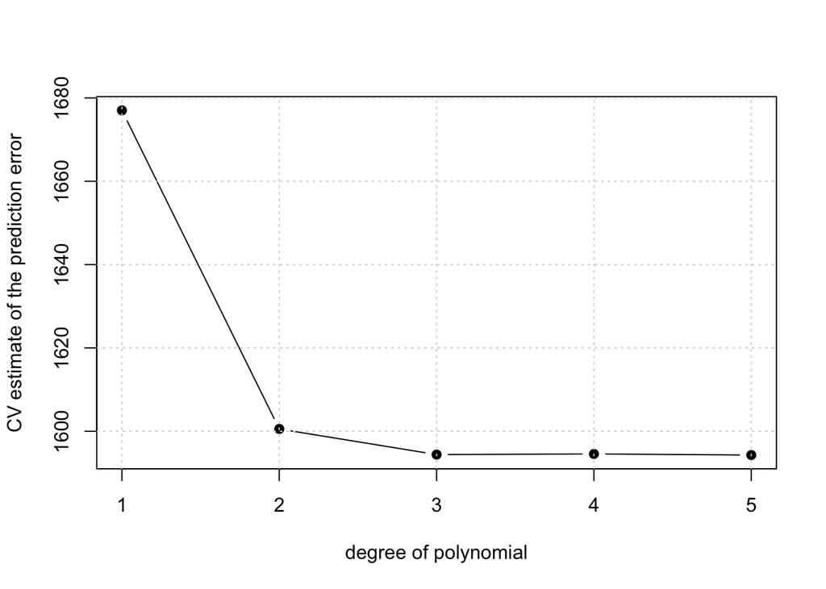

```r
plot(1:5, cv_error_poly, pch = 19, type = "b", xlab = "degree of polynomial", ylab = "CV estimate of the prediction error")
grid()
```

```r
# ANOVA comparison
lm.fit1 <- lm(wage ~ poly(age, 1), data = Wage)
lm.fit2 <- lm(wage ~ poly(age, 2), data = Wage)
lm.fit3 <- lm(wage ~ poly(age, 3), data = Wage)
lm.fit4 <- lm(wage ~ poly(age, 4), data = Wage)
lm.fit5 <- lm(wage ~ poly(age, 5), data = Wage)
anova(lm.fit1, lm.fit2, lm.fit3, lm.fit4, lm.fit5)
```

```
## Analysis of Variance Table
##
## Model 1: wage ~ poly(age, 1)
## Model 2: wage ~ poly(age, 2)
## Model 3: wage ~ poly(age, 3)
## Model 4: wage ~ poly(age, 4)
## Model 5: wage ~ poly(age, 5)
##   Res.Df     RSS Df Sum of Sq        F    Pr(>F)
## 1   2998 5022216
## 2   2997 4793430  1    228786 143.5931 < 2.2e-16 ***
## 3   2996 4777674  1     15756   9.8888  0.001679 **
## 4   2995 4771604  1      6070   3.8098  0.051046 .
## 5   2994 4770322  1      1283   0.8050  0.369682
## ---
## Signif. codes:  0 '***' 0.001 '**' 0.01 '*' 0.05 '.' 0.1 ' ' 1
```

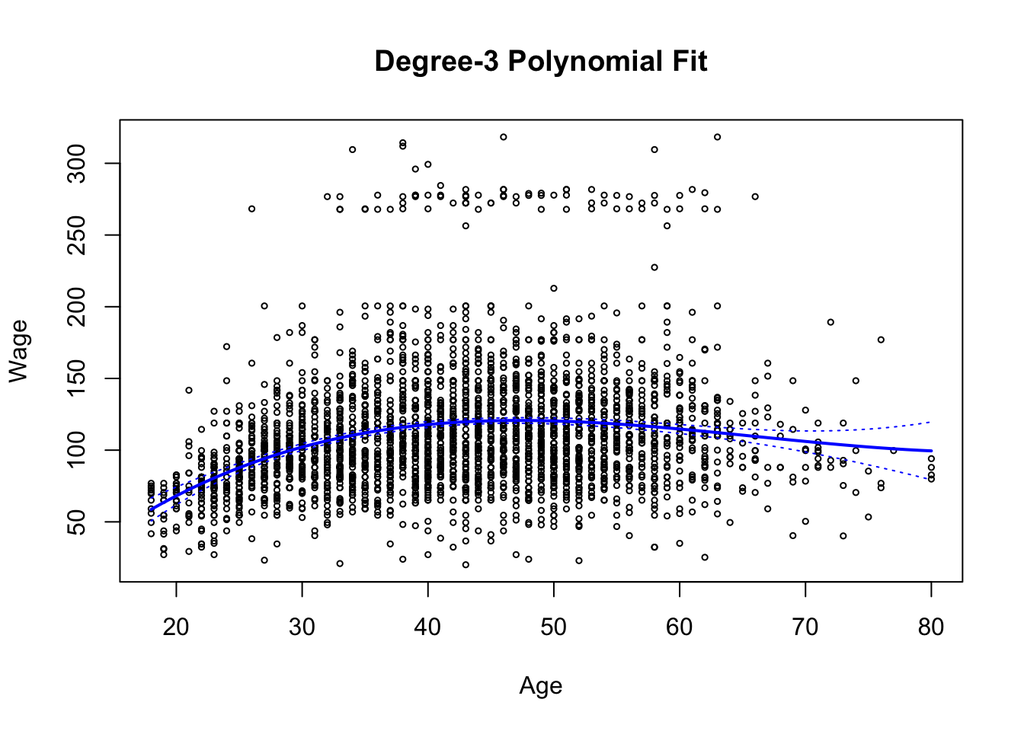

```r
# Plot best polynomial fit (degree = 3)
agelims <- range(Wage$age)
age.grid <- seq(from = agelims[1], to = agelims[2])
preds <- predict(lm.fit3, newdata = data.frame(age = age.grid), se = TRUE)
se.bands <- cbind(preds$fit + 2 * preds$se.fit, preds$fit - 2 * preds$se.fit)

plot(Wage$age, Wage$wage, xlim = agelims, cex = 0.5, xlab = "Age", ylab = "Wage")
title("Degree-3 Polynomial Fit")
lines(age.grid, preds$fit, lwd = 2, col = "blue")
matlines(age.grid, se.bands, lwd = 1, col = "blue", lty = 3)
```

#### (b) Step function with CV

The best number of cuts choosed by CV is 8

```r
set.seed(9)

cv_error_step <- rep(NA, 9)
for (i in 2:10) {
  Wage$age.cut <- cut(Wage$age, breaks = i)
  fit <- glm(wage ~ age.cut, data = Wage)
  cv_error_step[i - 1] <- cv.glm(Wage, fit, K = 10)$delta[1]
}
best_cut <- which.min(cv_error_step) + 1
print(paste("Best number of cuts:", best_cut))
```

```
## [1] "Best number of cuts: 8"
```

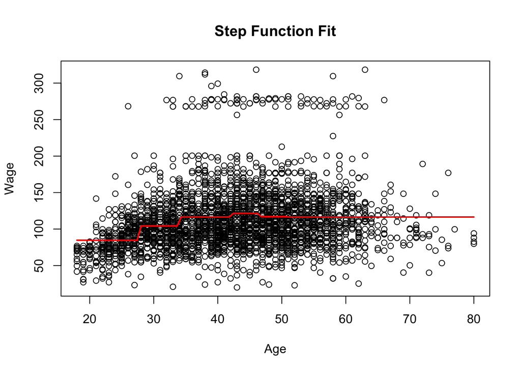

```r
# Fit step function with best number of cuts
breaks <- quantile(Wage$age, probs = seq(0, 1, length.out = best_cut + 1))
Wage$age.cut <- cut(Wage$age, breaks = breaks, include.lowest = TRUE)
step.fit <- glm(wage ~ age.cut, data = Wage)

# Plot step function fit
age.grid <- seq(from = min(Wage$age), to = max(Wage$age), length.out = 100)

# Apply same cuts to new data
newdata <- data.frame(age = age.grid)
newdata$age.cut <- cut(newdata$age, breaks = breaks, include.lowest = TRUE)

# Predict using step function
step.pred <- predict(step.fit, newdata = newdata)

# Plot
plot(wage ~ age, data = Wage, xlab = "Age", ylab = "Wage")
title("Step Function Fit")
lines(age.grid, step.pred, col = "red", lwd = 2)
```

### Applied: 9

#### (a)

All terms of the cubic polynomial are significant (p-values are less than 0.001). This shows that the relationship between dis and nox is not a simple linear relationship, but has a nonlinear trend.

The nonlinear relationship in the plot shows as: when “dis” increases, “nox” first decreases rapidly, then stabilizes, and then decreases slightly.

Multiple R-squared: 0.7148, Adjusted R-squared: 0.7131

The goodness of fit is high, indicating that the polynomial model adequately explains the data, explaining approximately 71.5% of the variance.

```r
data(Boston)

fit_a <- lm(nox ~ poly(dis, 3), data = Boston)
summary(fit_a)
```

```
##
## Call:
## lm(formula = nox ~ poly(dis, 3), data = Boston)
##
## Residuals:
##       Min        1Q    Median        3Q       Max
## -0.121130 -0.040619 -0.009738  0.023385  0.194904
##
## Coefficients:
##                Estimate Std. Error t value Pr(>|t|)
## (Intercept)    0.554695   0.002759 201.021  < 2e-16 ***
## poly(dis, 3)1 -2.003096   0.062071 -32.271  < 2e-16 ***
## poly(dis, 3)2  0.856330   0.062071  13.796  < 2e-16 ***
## poly(dis, 3)3 -0.318049   0.062071  -5.124 4.27e-07 ***
## ---
## Signif. codes:  0 '***' 0.001 '**' 0.01 '*' 0.05 '.' 0.1 ' ' 1
##
## Residual standard error: 0.06207 on 502 degrees of freedom
## Multiple R-squared:  0.7148, Adjusted R-squared:  0.7131
## F-statistic: 419.3 on 3 and 502 DF,  p-value: < 2.2e-16
```

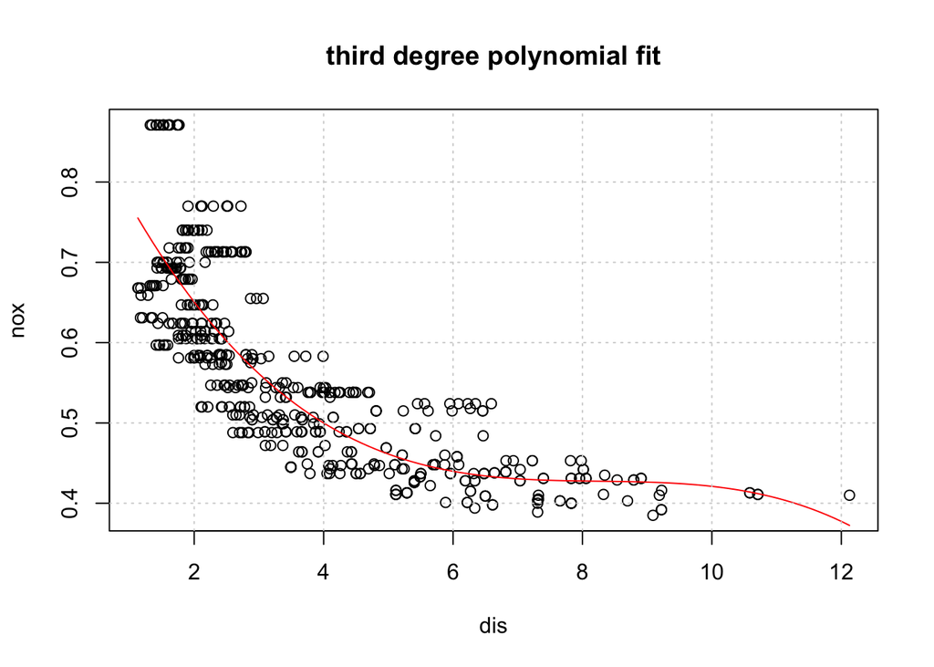

```r
plot(nox ~ dis, data = Boston,
     xlab = "dis", ylab = "nox",
     main = "third degree polynomial fit")

dis_range <- range(Boston$dis)
dis_samples <- seq(from = dis_range[1], to = dis_range[2], length.out = 100)
y_hat <- predict(fit_a, newdata = list(dis = dis_samples))

lines(dis_samples, y_hat, col = "red")
grid()
```

#### (b)

From the output, as the degree increased, the RSS decreased steadily, indicating improved fit on the training data. However, the marginal reduction in RSS became negligible after degree 3, suggesting that increasing complexity beyond that point may lead to overfitting.

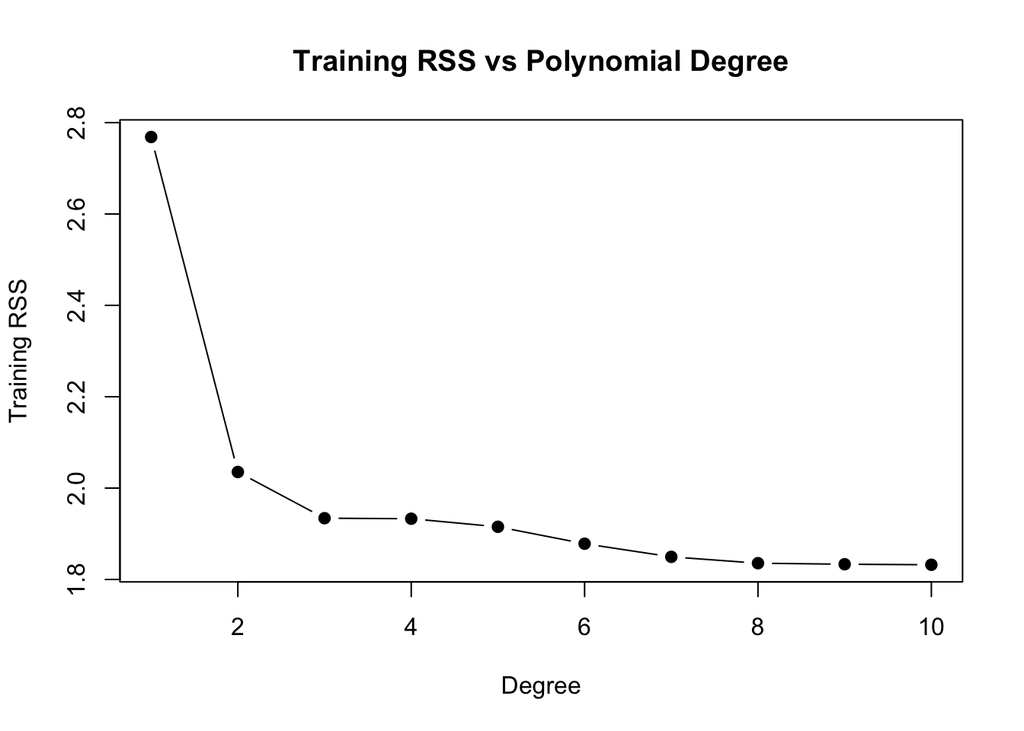

```r
d_max <- 10

# Training RSS for degrees 1 to 10
training_rss <- rep(NA, d_max)
for (d in 1:d_max) {
    m <- lm(nox ~ poly(dis, d), data = Boston)
    training_rss[d] <- sum((m$residuals)^2)
}

plot(1:d_max, training_rss, type = "b", pch = 19, xlab = "Degree", ylab = "Training RSS")
title("Training RSS vs Polynomial Degree")
```

```r
# Output the RSS for each degree
rss_df <- data.frame(Degree = 1:10, Training_RSS = training_rss)
print(rss_df)
```

```
##    Degree Training_RSS
## 1       1     2.768563
## 2       2     2.035262
## 3       3     1.934107
## 4       4     1.932981
## 5       5     1.915290
## 6       6     1.878257
## 7       7     1.849484
## 8       8     1.835630
## 9       9     1.833331
## 10     10     1.832171
```

#### (c)

The plot shows that the CV error initially decreases slightly and reaches its minimum around degree 3. After that, the error begins to increase, especially at degrees 7, 9, and 10, indicating potential overfitting.

The optimal degree selected by CV would likely be degree 3. This result aligns with the RSS plot in (b), which showed decreasing returns in training error beyond degree 3.

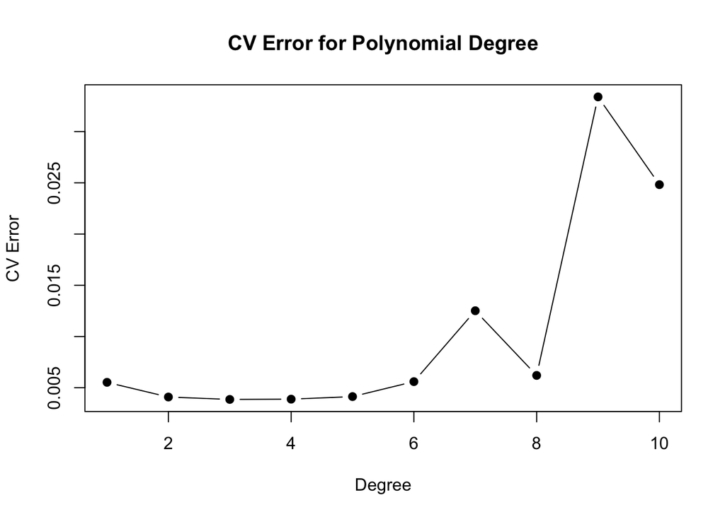

```r
set.seed(9)

d_max <- 10
cv_error <- rep(NA, d_max)

for (d in 1:d_max) {
  glm.fit <- glm(nox ~ poly(dis, d), data = Boston)
  cv_error[d] <- cv.glm(Boston, glm.fit, K = 10)$delta[1]
}

plot(1:d_max, cv_error, type = "b", pch = 19,
     xlab = "Degree", ylab = "CV Error",
     main = "CV Error for Polynomial Degree")
```

```r
which.min(cv_error)
```

```
## [1] 3
```

#### (d)

Output:

Using 4 df, all terms are significant.

Multiple R-squared: 0.7164, Adjusted R-squared: 0.7142

The goodness of fit is high, indicating that the polynomial model adequately explains the data, explaining approximately 71.6% of the variance.

How to choose the knots?

Knots are chosen based on quantiles of the data.

df = #knots + degree and the default degree is 3 (cubic)

So, bs(dis, df = 4) automatically selects 1 knot over the range of “dis”.

I use “attr(bs(Boston$dis, df = 4),”knots”)” to check the knot, the output “3.20745” means the knot is at “dis = 3.20745”

```r
fit_d <- lm(nox ~ bs(dis, df = 4), data = Boston)
summary(fit_d)
```

```
##
## Call:
## lm(formula = nox ~ bs(dis, df = 4), data = Boston)
##
## Residuals:
##       Min        1Q    Median        3Q       Max
## -0.124622 -0.039259 -0.008514  0.020850  0.193891
##
## Coefficients:
##                  Estimate Std. Error t value Pr(>|t|)
## (Intercept)       0.73447    0.01460  50.306  < 2e-16 ***
## bs(dis, df = 4)1 -0.05810    0.02186  -2.658  0.00812 **
## bs(dis, df = 4)2 -0.46356    0.02366 -19.596  < 2e-16 ***
## bs(dis, df = 4)3 -0.19979    0.04311  -4.634 4.58e-06 ***
## bs(dis, df = 4)4 -0.38881    0.04551  -8.544  < 2e-16 ***
## ---
## Signif. codes:  0 '***' 0.001 '**' 0.01 '*' 0.05 '.' 0.1 ' ' 1
##
## Residual standard error: 0.06195 on 501 degrees of freedom
## Multiple R-squared:  0.7164, Adjusted R-squared:  0.7142
## F-statistic: 316.5 on 4 and 501 DF,  p-value: < 2.2e-16
```

```r
attr(bs(Boston$dis, df = 4), "knots")
```

```
## [1] 3.20745
```

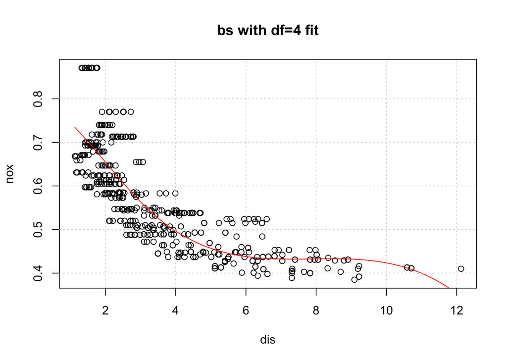

```r
plot(Boston$dis, Boston$nox, xlab = "dis", ylab = "nox",
     main = "bs with df=4 fit")

dis_range <- range(Boston$dis)
dis_samples <- seq(from = dis_range[1], to = dis_range[2], length.out = 100)
y_hat <- predict(fit_d, newdata = data.frame(dis = dis_samples))

lines(dis_samples, y_hat, col = "red")
grid()
```

#### (e)

From the result, as the df increased from 3 to 20, RSS decreased from 1.93 to 1.78.

The reduction in RSS was most significant when increasing from 3 to 10 df.

Beyond df = 10, the gain was minimal, suggesting that higher flexibility may lead to overfitting without substantial improvement.

Therefore, 10 degrees of freedom may offer a good trade-off between bias and variance in this case.

The same in the plot: The curve with low df (such as df = 3) is too smooth and cannot capture the nonlinear structure between dis-nox. The curve with high df (such as df = 15, 20) fits more finely, but may not perform well on the test set.

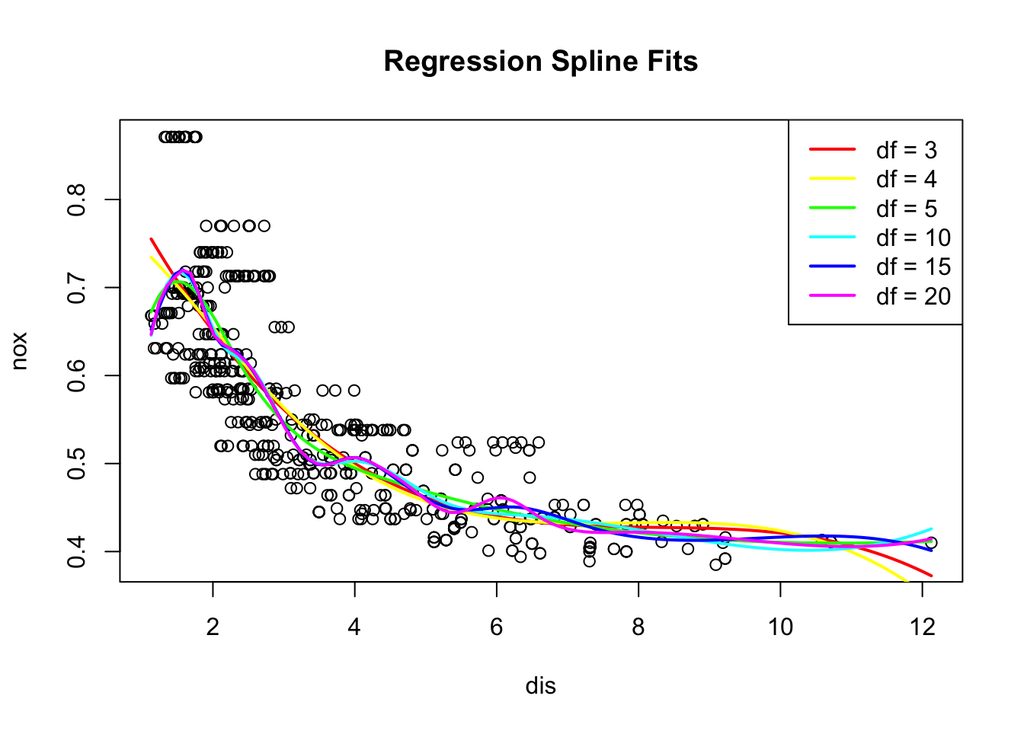

```r
dof_choices <- c(3, 4, 5, 10, 15, 20)
rss_values <- numeric(length(dof_choices))

plot(Boston$dis, Boston$nox, xlab = "dis", ylab = "nox",
     main = "Regression Spline Fits")

colors <- rainbow(length(dof_choices))
legend_labels <- c()

for (i in seq_along(dof_choices)) {
  df_val <- dof_choices[i]
  fit <- lm(nox ~ bs(dis, df = df_val), data = Boston)

  rss_values[i] <- sum(residuals(fit)^2)

  dis.grid <- seq(min(Boston$dis), max(Boston$dis), length.out = 100)
  preds <- predict(fit, newdata = data.frame(dis = dis.grid))
  lines(dis.grid, preds, col = colors[i], lwd = 2)

  legend_labels[i] <- paste("df =", df_val)
}

legend("topright", legend = legend_labels, col = colors, lwd = 2)
```

```r
print(data.frame(dof = dof_choices, RSS = round(rss_values, 2)))
```

```
##   dof  RSS
## 1   3 1.93
## 2   4 1.92
## 3   5 1.84
## 4  10 1.79
## 5  15 1.78
## 6  20 1.78
```

#### (f)

I performed cross-validation and the best degrees of freedom based on CV is 10.

This result is consistent with the RSS trend in (e), where the RSS plateaued after df = 10. Therefore, df = 10 appears to be an appropriate complexity level for modeling the relationship between “dis” and “nox”.

```r
set.seed(9)

dof_choices <- c(3, 4, 5, 6, 7, 8, 9, 10, 11, 12)
cv_errors <- numeric(length(dof_choices))

for (i in seq_along(dof_choices)) {
  df_val <- dof_choices[i]
  glm.fit <- glm(nox ~ bs(dis, df = df_val), data = Boston)
  cv_result <- cv.glm(Boston, glm.fit, K = 10)
  cv_errors[i] <- cv_result$delta[1]
}
```

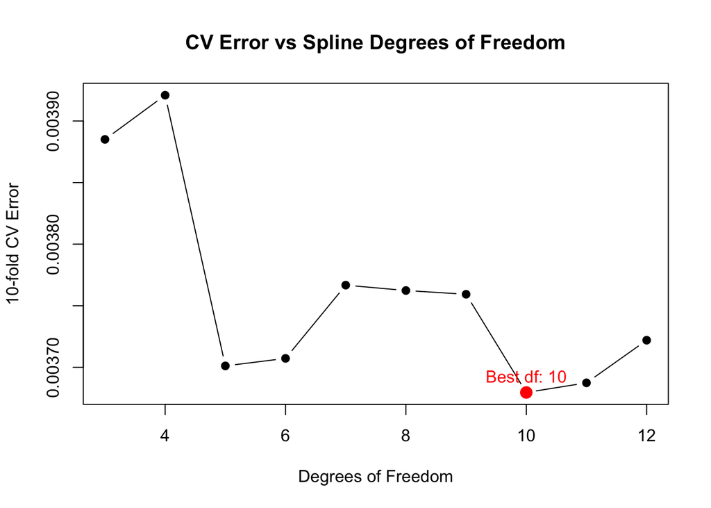

```r
plot(dof_choices, cv_errors, type = "b", pch = 19,
     xlab = "Degrees of Freedom", ylab = "10-fold CV Error",
     main = "CV Error vs Spline Degrees of Freedom")

best_df <- dof_choices[which.min(cv_errors)]
points(best_df, min(cv_errors), col = "red", pch = 19, cex = 1.5)
text(best_df, min(cv_errors), labels = paste("Best df:", best_df), pos = 3, col = "red")
```

```r
print(paste("Best degrees of freedom based on CV:", best_df))
```

```
## [1] "Best degrees of freedom based on CV: 10"
```

### Applied: 10

#### (a)

There are 17 Variables (and intercept) in all.

The model selection criterion I used was BIC.

Best model size choosen by BIC is 10, with coefficients given by:

“PrivateYes” “Apps” “Accept” “Top10perc” “F.Undergrad” “Room.Board” “Terminal” “perc.alumni” “Expend” “Grad.Rate”

```r
data("College")
sum(is.na(College))
```

```
## [1] 0
```

```r
# split 70% as training, 30% as test
set.seed(9)
train <- sample(1:nrow(College), 0.7*nrow(College))

College_train <- College[train,]
College_test <- College[-train,]

x <- College[, !names(College) %in% "Outstate"]
y <- College$Outstate
x_train <- as.matrix(College_train[, !names(College_train) %in% "Outstate"])
y_train <- as.numeric(College_train$Outstate)
x_test <- as.matrix(College_test[, !names(College_test) %in% "Outstate"])
y_test <- as.numeric(College_test$Outstate)

fit_forward <- regsubsets(Outstate ~ ., data = College_train,
                             nvmax = ncol(College_train) - 1, method = "forward")
fit_summary <- summary(fit_forward)
fit_summary
```

```
## Subset selection object
## Call: regsubsets.formula(Outstate ~ ., data = College_train, nvmax = ncol(College_train) -
##     1, method = "forward")
## 17 Variables  (and intercept)
##             Forced in Forced out
## PrivateYes      FALSE      FALSE
## Apps            FALSE      FALSE
## Accept          FALSE      FALSE
## Enroll          FALSE      FALSE
## Top10perc       FALSE      FALSE
## Top25perc       FALSE      FALSE
## F.Undergrad     FALSE      FALSE
## P.Undergrad     FALSE      FALSE
## Room.Board      FALSE      FALSE
## Books           FALSE      FALSE
## Personal        FALSE      FALSE
## PhD             FALSE      FALSE
## Terminal        FALSE      FALSE
## S.F.Ratio       FALSE      FALSE
## perc.alumni     FALSE      FALSE
## Expend          FALSE      FALSE
## Grad.Rate       FALSE      FALSE
## 1 subsets of each size up to 17
## Selection Algorithm: forward
##           PrivateYes Apps Accept Enroll Top10perc Top25perc F.Undergrad
## 1  ( 1 )  " "        " "  " "    " "    " "       " "       " "
## 2  ( 1 )  "*"        " "  " "    " "    " "       " "       " "
## 3  ( 1 )  "*"        " "  " "    " "    " "       " "       " "
## 4  ( 1 )  "*"        " "  " "    " "    " "       " "       " "
## 5  ( 1 )  "*"        " "  " "    " "    " "       " "       " "
## 6  ( 1 )  "*"        " "  " "    " "    " "       " "       " "
## 7  ( 1 )  "*"        " "  "*"    " "    " "       " "       " "
## 8  ( 1 )  "*"        "*"  "*"    " "    " "       " "       " "
## 9  ( 1 )  "*"        "*"  "*"    " "    " "       " "       "*"
## 10  ( 1 ) "*"        "*"  "*"    " "    "*"       " "       "*"
## 11  ( 1 ) "*"        "*"  "*"    " "    "*"       " "       "*"
## 12  ( 1 ) "*"        "*"  "*"    " "    "*"       " "       "*"
## 13  ( 1 ) "*"        "*"  "*"    " "    "*"       " "       "*"
## 14  ( 1 ) "*"        "*"  "*"    "*"    "*"       " "       "*"
## 15  ( 1 ) "*"        "*"  "*"    "*"    "*"       "*"       "*"
```

[output cut: 23 more lines]

```
## 3  ( 1 )  " "         "*"    " "
## 4  ( 1 )  "*"         "*"    " "
## 5  ( 1 )  "*"         "*"    " "
## 6  ( 1 )  "*"         "*"    "*"
## 7  ( 1 )  "*"         "*"    "*"
## 8  ( 1 )  "*"         "*"    "*"
## 9  ( 1 )  "*"         "*"    "*"
## 10  ( 1 ) "*"         "*"    "*"
## 11  ( 1 ) "*"         "*"    "*"
## 12  ( 1 ) "*"         "*"    "*"
## 13  ( 1 ) "*"         "*"    "*"
## 14  ( 1 ) "*"         "*"    "*"
## 15  ( 1 ) "*"         "*"    "*"
## 16  ( 1 ) "*"         "*"    "*"
## 17  ( 1 ) "*"         "*"    "*"
```

```r
# Identify best model by BIC
best_model_size <- which.min(fit_summary$bic)
best_model_vars <- names(coef(fit_forward, best_model_size))[-1]  # remove intercept
print(paste("Best model size (by BIC):", best_model_size))
```

```
## [1] "Best model size (by BIC): 10"
```

```r
print("Selected predictors:")
```

```
## [1] "Selected predictors:"
```

```r
print(best_model_vars)
```

```
##  [1] "PrivateYes"  "Apps"        "Accept"      "Top10perc"   "F.Undergrad"
##  [6] "Room.Board"  "Terminal"    "perc.alumni" "Expend"      "Grad.Rate"
```

#### (b)

Each plot shows the estimated smooth function (s(variable)) of a predictor on the “Outstate”, with 95% CIs (dashed lines).

“PrivateYes” is a categorical variable. There is a large vertical jump between No and Yes, suggesting that private colleges tend to have significantly higher out-of-state tuition than public ones.

Variables like “Expend” and “Grad.Rate” display smooth, non-linear influences.

The GAM captures both linear and non-linear relationships, showing its flexibly model complex effects without assuming strict linearity.

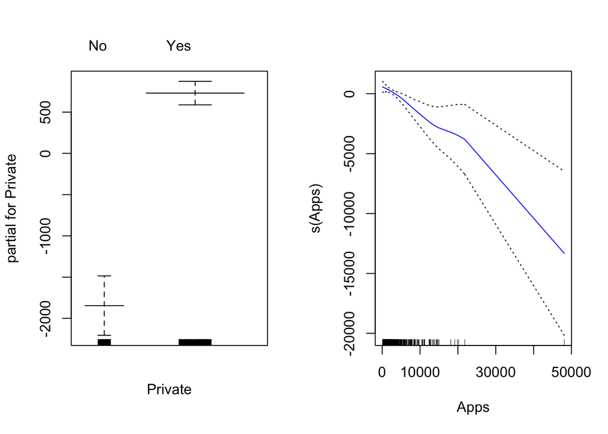

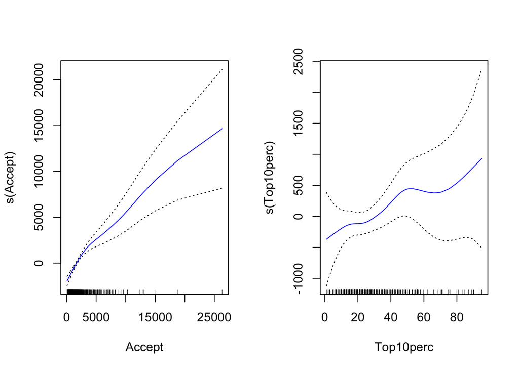

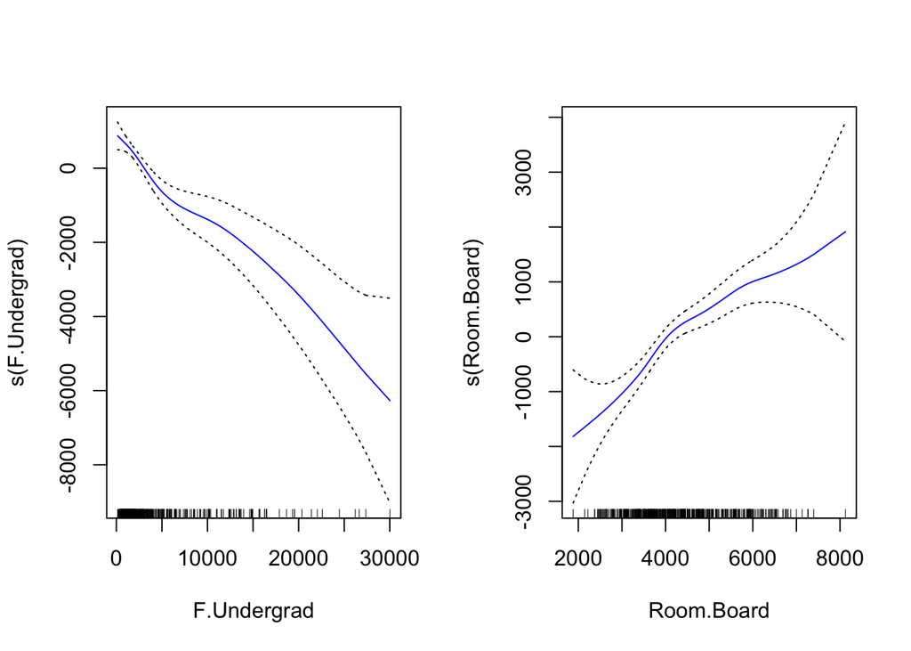

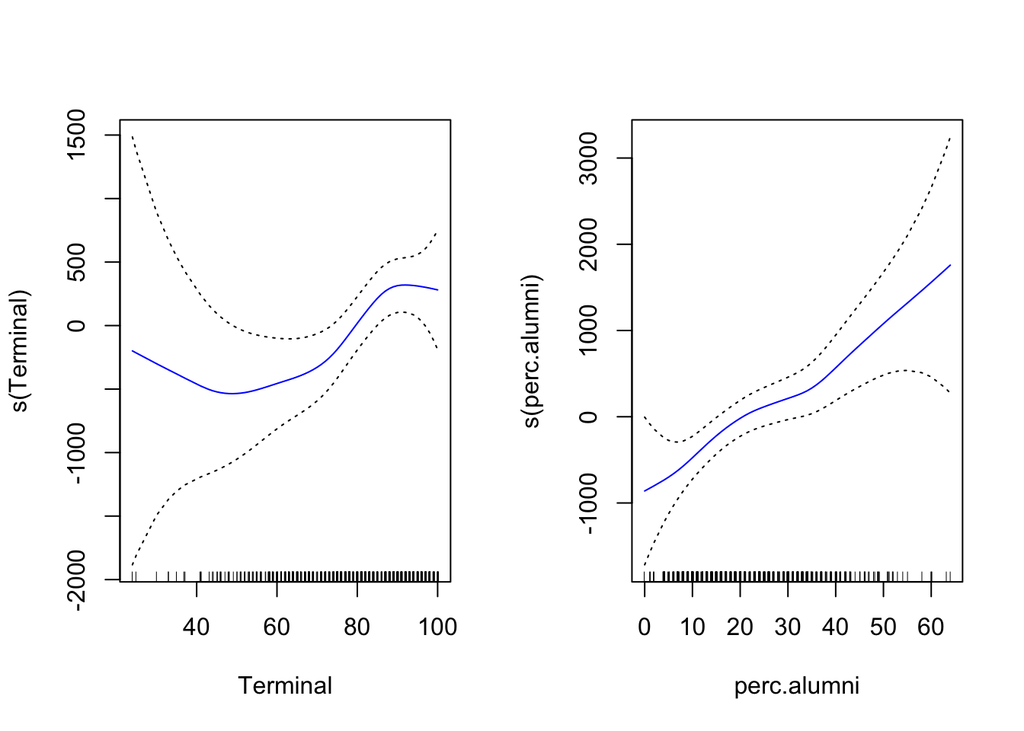

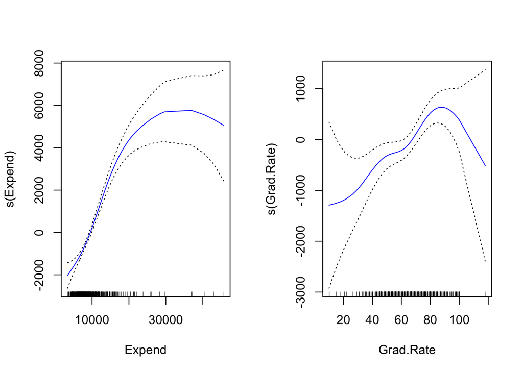

```r
numeric_vars <- names(College)[sapply(College, is.numeric)]

best_model_vars[best_model_vars == "PrivateYes"] <- "Private"

formula_terms <- sapply(best_model_vars, function(var) {
  if (var %in% numeric_vars) {
    paste0("s(", var, ")")
  } else {
    var
  }
})

gam_formula <- as.formula(paste("Outstate ~", paste(formula_terms, collapse = " + ")))

# Fit GAM
fit_gam <- gam(gam_formula, data = College_train)

# Plot the GAM fit
par(mfrow = c(1, 2))
plot(fit_gam, se = TRUE, col = "blue")
```

#### (c)

Test MSE of the GAM: 3906866.28

This means the average squared error between the predicted and actual Outstate tuition on the test set is about 3.91 million. Since the tuition values are mostly between 5,000 and 20,000, this MSE suggests moderate prediction error — but not excellent.

```r
pred_gam <- predict(fit_gam, newdata = College_test)

# Compute test MSE
mse_gam <- mean((College_test$Outstate - pred_gam)^2)
print(paste("Test MSE of the GAM:", round(mse_gam, 2)))
```

```
## [1] "Test MSE of the GAM: 3906866.28"
```

#### (d)

From the output:

The variable “Private” does not appear in the “Nonparametric Effects” section because it is a binary categorical variable.

There is strong evidence of non-linear relationships between “Outstate” and “Expend” (very strong), “Accept”, “Grad.Rate”, “F.Undergrad”

There is marginal evidence for “Room.Board”

Other variables, including “Apps”, “Top10perc”, “perc.alumni”, and “Terminal”, do not show significant non-linear effects — a linear fit is sufficient.

While the smoothing plot for “Terminal” shows apparent curvature, the corresponding nonparametric p-value (p = 0.206) suggests that this nonlinearity is not statistically significant. This indicates that the observed curve might be due to random variation or overfitting, rather than reflecting a true nonlinear relationship in the population.

```r
summary(fit_gam)
```

```
##
## Call: gam(formula = gam_formula, data = College_train)
## Deviance Residuals:
##     Min      1Q  Median      3Q     Max
## -6217.4 -1098.0   128.2  1156.5  4406.7
##
## (Dispersion Parameter for gaussian family taken to be 2988392)
##
##     Null Deviance: 8876881505 on 542 degrees of freedom
## Residual Deviance: 1509139709 on 505.0005 degrees of freedom
## AIC: 9675.835
##
## Number of Local Scoring Iterations: NA
##
## Anova for Parametric Effects
##                 Df     Sum Sq    Mean Sq F value    Pr(>F)
## Private          1 2868535310 2868535310 959.892 < 2.2e-16 ***
## s(Apps)          1  853922855  853922855 285.747 < 2.2e-16 ***
## s(Accept)        1   75417747   75417747  25.237 7.047e-07 ***
## s(Top10perc)     1  932491549  932491549 312.038 < 2.2e-16 ***
## s(F.Undergrad)   1  263583108  263583108  88.202 < 2.2e-16 ***
## s(Room.Board)    1  603377475  603377475 201.907 < 2.2e-16 ***
## s(Terminal)      1  138182322  138182322  46.240 2.964e-11 ***
## s(perc.alumni)   1  171231316  171231316  57.299 1.791e-13 ***
## s(Expend)        1  492140921  492140921 164.684 < 2.2e-16 ***
## s(Grad.Rate)     1   51008972   51008972  17.069 4.219e-05 ***
## Residuals      505 1509139709    2988392
## ---
## Signif. codes:  0 '***' 0.001 '**' 0.01 '*' 0.05 '.' 0.1 ' ' 1
##
## Anova for Nonparametric Effects
##                Npar Df  Npar F     Pr(F)
## (Intercept)
## Private
## s(Apps)              3  1.7350   0.15884
## s(Accept)            3  9.2972 5.406e-06 ***
## s(Top10perc)         3  1.0729   0.36011
## s(F.Undergrad)       3  2.8004   0.03948 *
## s(Room.Board)        3  2.4834   0.06010 .
## s(Terminal)          3  1.5276   0.20642
## s(perc.alumni)       3  0.6541   0.58068
## s(Expend)            3 19.0228 1.059e-11 ***
## s(Grad.Rate)         3  3.4692   0.01609 *
## ---
## Signif. codes:  0 '***' 0.001 '**' 0.01 '*' 0.05 '.' 0.1 ' ' 1
```